# Caparezza Sentiment Analysis

In this notebook, a text mining process on the works of the Italian singer **Caparezza** will be performed, with the intention of finding recurring themes throughout his albums and songs.

Much of the inspiration for this project comes from [this repository](https://tm4ss.github.io/docs/index.html).

## Get the lyrics

```r
library(geniusr)
library(tidyverse)
library(tidytext)
library(quanteda)
library(quanteda.textstats)
library(udpipe)
```

```r
library(wordcloud)
library(textdata)
library(reshape2)
library(igraph)
```

Lyrics for the songs can be obtained using the *geniusr* package, available at https://github.com/ewenme/geniusr. Follow the instructions at that link to set up an API key and use it to query the Genius lyrics database.

```r
Sys.setenv(GENIUS_API_TOKEN = "mjJVgXu4_yQNgYXFYV72Q9uXCIdTFFq3s3c8PPcUT6G1tlAedbpg0dpdZv6KJQW7")

artist_id <- search_artist("Caparezza")$artist_id
artist_songs <- get_artist_songs(artist_id)

songs_ids <- c()
for (song in artist_songs$content) {
  song_id <- song$id
  songs_ids <- songs_ids %>% append(song_id)
}

songs_titles <- c()
songs_albums <- c()
songs_lyrics <- c()
for (i in 1:length(songs_ids)) {
  cat("Getting", i, "of", length(songs_ids), "id:", songs_ids[i], "\n")
  song <- get_song(songs_ids[i])$content
  song_title <- song$title
  song_album <- song$album$name
  song_lyrics <- list(get_lyrics_id(songs_ids[i]))
  # some songs have no album associated with them, so we won't consider them
  # additionally, some songs have no lyrics, we are excluding them too
  if (!is.null(song_album) & nrow(song_lyrics[[1]]) != 0){
    songs_titles <- songs_titles %>% append(song_title)
    songs_albums <- songs_albums %>% append(song_album)
    songs_lyrics <- songs_lyrics %>% append(song_lyrics)
  }
}
```

[output not shown]

[output cut: 165 more lines]

[output not shown]

```r
# collapse all lyrics lines into a single text
for (i in 1:length(songs_lyrics)){
  songs_lyrics[[i]] <- songs_lyrics[[i]]$line %>% paste(collapse = "\n")
}

songs_lyrics <- unlist(songs_lyrics)

songs <- data.frame(title = songs_titles, album = songs_albums, lyrics = songs_lyrics)
```

Now we have got a dataframe with data about each individual song. Let’s look at the first element.

```r
songs %>% head(1)
```

```
##          title                      album
## 1 Abiura Di Me Le Dimensioni Del Mio Caos
##                                                                                                                                                                                                                                                                                                          …
## 1 Se pensi che possa cambiare il mondo, ti sbagli alla grande\nÈ già tanto se mi cambio le mutande\nVoglio solo darti un'emicrania lancinante\nFino a che non salti nel vuoto come uno stuntman\nPensavi che sparassi palle? Bravo\nIo sono il drago di Puzzle Bobble\nCome Crash mi piace rompere le sca…
```

Songs are ordered alphabetically by the title, and the first one appears to be *Abiura Di Me*.

Let’s do some cleaning: we are going to ignore alternative versions of the same song, such as live versions, radio edits and remixes. We are also keeping only the main albums, ignoring specials or compilations.

```r
albums <- c("?! (Caparezza ?!)", "Verità Supposte", "Habemus Capa",
            "Le Dimensioni Del Mio Caos", "Il Sogno Eretico", "Museica",
            "Prisoner 709", "Exuvia")
songs <- songs %>%
  filter(!grepl("Live|Radio Edit|Radio Version|Remix|RMX", title) & album %in% albums)
```

Finally, we order songs chronologically by the album, then add an id for each song.

```r
songs <- songs %>% arrange(match(album, albums), title)
doc_ids <- vector()
for(i in 1:nrow(songs)){
  id <- paste("doc", toString(i), sep = "")
  doc_ids <- doc_ids %>% append(id)
}
songs <- songs %>% mutate(doc_id = doc_ids, .before = 1)
```

Let’s check the number of songs for each album.

```r
table(songs$album) %>% as.data.frame() %>% arrange(-Freq)
```

```
##                         Var1 Freq
## 1                     Exuvia   19
## 2                    Museica   19
## 3               Habemus Capa   18
## 4           Il Sogno Eretico   16
## 5               Prisoner 709   16
## 6            Verità Supposte   15
## 7          ?! (Caparezza ?!)   14
## 8 Le Dimensioni Del Mio Caos   14
```

The frequencies are correct, as every Caparezza fan will recognize.

## Text pre-processing

Now we start with some text pre-processing: let’s create a corpus from the songs’ lyrics.

```r
caparezza_corpus <- corpus(songs$lyrics, docnames = songs$id)
summary(caparezza_corpus)
```

```
## Corpus consisting of 131 documents, showing 100 documents:
##
##     Text Types Tokens Sentences
##    text1   298    551         3
##    text2   322    744         8
##    text3   321    643         7
##    text4   251    585         1
##    text5   279    573         7
##    text6    49     57         1
##    text7   237    484         1
##    text8   270    584        10
##    text9   314    703         3
##   text10   206    486         1
##   text11   205    413         1
##   text12   232    709         4
##   text13   195    499        13
##   text14   262    607         2
##   text15   244    440         2
##   text16   181    392         7
##   text17   184    437         2
##   text18   258    500         4
##   text19   235    585         2
##   text20   233    566         4
##   text21   261    416         3
##   text22   273    609        14
##   text23   291    646         5
##   text24   286    556         2
##   text25   281    475         5
##   text26   323    645         6
##   text27   255    543         3
##   text28   220    404         3
##   text29   234    569         4
##   text30   240    525         2
##   text31   258    648        31
##   text32   232    633        19
##   text33   403    713        15
##   text34   270    537         1
##   text35   278    521        13
##   text36   302    593         2
##   text37   305    568         4
```

[output cut: 48 more lines]

```
##   text86   293    465         2
##   text87   194    498         3
##   text88   186    385         1
##   text89   243    578        24
##   text90   228    405         2
##   text91   225    572         1
##   text92   196    436        11
##   text93   261    503         8
##   text94   236    414        18
##   text95   252    625         6
##   text96   312    732         5
##   text97   227    409         2
##   text98   263    607         2
##   text99   292    508         3
##  text100   272    618         2
```

```r
cat(as.character(caparezza_corpus[1]))
```

```
## Non rappresento che me stesso perché questo sono
## Se sbaglio mi perdono
## Prima di essere MC sii uomo mi ripeto
## Fa' mille passi indietro e il risultato
## È che non mi sento per niente arrivato
## Anzi sto bene anche a cibarmi degli avanzi dei padroni sazi
## E mi piglio spazi se me li concedono
## Sennò me li lascio fottere
## Detesto combattere, che vuoi farci? È carattere
## Sbattere testa contro le porte è il mio forte
## Sono il gallo da spennare per chi bara alle carte
## Giullare di corte messo a morte e poi salvato da una chance
## Lascerei la musica, ma 'sta stronza mi fa le avances
## E non resisto, mi do in pasto alla lingua che mastico
## Investo in testi che vesto di stracci e mi riduco al lastrico
## Nella testa un mistico richiamo, poema indiano
## Che mi prende per mano e mi dice: "Andiamo!"
## Se non rispondono al tuo appello, cammina solo, cammina solo
## Se non rispondono al tuo appello, cammina solo, cammina solo
## Detesto l'odio ma l'ho visto venir fuori
## Dagli occhi di alcuni interlocutori
## Hanno motivi loro e i loro sguardi sono come lastre di ghiaccio
## Si scioglieranno a poco a poco al fuoco di ciò che faccio
## Se il rancore resta onestamente non mi resta niente da fare
## Che alzare i tacchi e andare, menare via
## Cullarmi nel tepore di ogni mano che ha stretto la mia
## Avere Dio come terapia
## Sarà la miopia ma faccio fatica a inquadrare la retta via
## Voglio te per compagnia
## Portami in balia della gente, dove c'è amore
## Lì sarò presente anch'io
## Ti cedo il posto mio
## Non è per vincere che vivo ma per ardere
## Perciò se dovrò perdere lasciatemi perdere e avrò perso
## Cosciente che non sono né peggiore né migliore di nessuno
## Finchè sarò diverso
## Se non rispondono al tuo appello, cammina solo, cammina solo
## Se non rispondono al tuo appello, cammina solo, cammina solo
## Se mi ritrovo sull'incudine, sotto un martello di solitudine
## Colpo su colpo come un polpo sullo scoglio muoio, ma ci farò l'abitudine
## Se non lo sai cominciai per scherzo
## Come un bimbo immobile nell'automobile con le mani sullo sterzo
## Verso nuovi orizzonti, sopra e sotto i ponti
## Davanti a piatti pronti, pagato con assegni fatti di saldi e sconti
## Tra re, regine e fanti cercai clemenza
## Mò non vado in vacanza prima di aver lasciato una testimonianza di ciò che sono
## Coi miei tanti nomi, le contraddizioni
## Appartengo ad una strana scena, quella degli esseri umani
## Credo ai meriti che conquisto, credo in Cristo perché l'ho visto
## Credo al rischio dell'incomprensione, credo nelle persone
## Nella consolazione, nella mia devozione, in ogni azione pacifica
## Detesto l'astio che ramifica, la cassa che lo amplifica
## Canto il mio Magnificat come un pazzo a mare e monti
## Ignoranti e colti, sperando che qualcuno ascolti
## Se non rispondono al tuo appello, cammina solo, cammina solo
## Se non rispondono al tuo appello, cammina solo, cammina solo
## Se non rispondono al tuo appello, cammina solo, cammina solo
## Se non rispondono al tuo appello, cammina solo, cammina solo
```

The first document of the corpus is the song “Cammina Solo” from *?!*, since we have ordered songs by album and then by title.

One of the main steps of lexical analysis is the removal of punctuation marks, numbers and symbols which are not useful towards the text interpretation.

The *quanteda* package offers some useful tools for these operations.

```r
corpus_tokens <- caparezza_corpus %>%
  quanteda::tokens(remove_punct = TRUE, remove_numbers = TRUE, remove_symbols = TRUE) %>%
  tokens_tolower()
```

Additionally, we would like to lemmatise: that is, to consider the *lemma* from which a word originates, instead of the world itself. For example, the infinitive forms of the verbs or the standard singular masculine adjective form are sufficient to express a concept, so we can safely use those instead of their derivatives.

```r
txt <- sapply(corpus_tokens, FUN=function(x) paste(x, collapse = "\n"))
udpipe_download_model(language = "italian-isdt", model_dir = "resources/")
```

```
##  - This model has been trained on version 2.5 of data from https://universaldependencies.org
```

```
##  - The model is distributed under the CC-BY-SA-NC license: https://creativecommons.org/licenses/by-nc-sa/4.0
```

```
##  - Visit https://github.com/jwijffels/udpipe.models.ud.2.5 for model license details.
```

```
##  - For a list of all models and their licenses (most models you can download with this package have either a CC-BY-SA or a CC-BY-SA-NC license) read the documentation at ?udpipe_download_model. For building your own models: visit the documentation by typing vignette('udpipe-train', package = 'udp…
```

```
##       language                                   file_model
## 1 italian-isdt resources//italian-isdt-ud-2.5-191206.udpipe
##                                                                                                                                   url
## 1 https://raw.githubusercontent.com/jwijffels/udpipe.models.ud.2.5/master/inst/udpipe-ud-2.5-191206/italian-isdt-ud-2.5-191206.udpipe
##   download_failed download_message
## 1           FALSE               OK
```

```r
lang_model <- udpipe_load_model(file = "resources/italian-isdt-ud-2.5-191206.udpipe")
outL <- udpipe_annotate(lang_model, x = txt, tokenizer = "vertical", trace = TRUE) %>%
  as.data.frame()
```

[output not shown]

[output cut: 76 more lines]

[output not shown]

```r
it_stopwords <- readLines("https://raw.githubusercontent.com/stopwords-iso/stopwords-it/master/stopwords-it.txt")
outL <- outL %>% filter(!(token %in% it_stopwords) & !(lemma %in% it_stopwords))
```

We have made use of the *UDPipe* library annotation function.

In the process, we have also removed *stopwords*, words that do not bring any meaningful addition to our texts, but are only necessary to connect other words and respect syntactic rules.

Let’s have a look at random sample of five elements of the output.

```r
outL %>% select(doc_id, token, lemma, upos) %>% sample_n(5)
```

```
##   doc_id     token     lemma upos
## 1  doc73   tortura   tortura NOUN
## 2 doc110       via       via  ADV
## 3 doc110       der       der  ADP
## 4  doc50 discovery discovery NOUN
## 5  doc54    urlava    urlare VERB
```

To further enhance our analysis, let’s focus only on nouns, proper nouns, adjectives and verbs.

```r
outL_reduced <- outL %>% filter(upos %in% c("NOUN", "PROPN", "ADJ", "VERB"))
```

Now we create a new corpus with the lemmatized lyrics.

```r
# fct_inorder preserves original order of the column
lemmatized_lyrics <- outL_reduced %>% group_by(doc_id = fct_inorder(doc_id)) %>%
  summarise(lemmatized = paste(lemma, collapse = " "))
songs <- songs %>% right_join(lemmatized_lyrics, by = "doc_id")

caparezza_corpus <- songs$lemmatized %>% corpus(docnames = songs$id)
```

One final step for text-processing consists in handling collocations, or multi-word units(MWUs). A collocation is a set of two or more words which are closely related and are often used together to express a single concept.

They can be identified through statistical, objective methods, like in this case.

```r
collocations <- caparezza_corpus %>% tokens() %>% textstat_collocations %>%
  arrange(-count) %>% head(10)
```

Looking at the collocations found by the function, we decide to take action on two of them, which seem to be clearly meant to be used together.

```r
DTM <- caparezza_corpus %>% tokens() %>% tokens_compound(collocations[c(4,6),]) %>%
  tokens_remove("") %>% dfm()
```

## Lexical Analysis

In the last step, we have created an object called DTM. This is the document-term matrix of our corpus: it’s a matrix which contains documents on its rows and terms on its columns. Every element of the matrix describes the number of occurrencies of the corresponding term inside the corresponding document.

```r
DTM
```

```
## Document-feature matrix of: 129 documents, 8,679 features (98.55% sparse) and 0 docvars.
##        features
## docs    rappresentare perdere mc ripetere passo risultato sentire arrivato arma
##   text1             1       4  1        1     1         1       1        1    2
##   text2             0       0  0        0     0         0       0        0    0
##   text3             0       0  0        0     0         0       0        0    0
##   text4             0       0  0        0     0         0       1        0    0
##   text5             0       0  0        0     0         0       0        0    0
##   text6             0       0  0        0     0         0       0        0    0
##        features
## docs    |
##   text1 2
##   text2 0
##   text3 0
##   text4 0
##   text5 0
##   text6 0
## [ reached max_ndoc ... 123 more documents, reached max_nfeat ... 8,669 more features ]
```

```r
DTM %>% dim()
```

```
## [1]  129 8679
```

We have got a total of 129 documents and 8679 unique terms in our corpus.

Let’s build a frequencies table for our terms and look at the most recurring ones.

```r
words <- colnames(DTM)
freqs <- colSums(DTM)
wordlist <- data.frame(words, freqs)
wordlist %>% arrange(-freqs) %>% head()
```

```
##           words freqs
## sapere   sapere   152
## vedere   vedere   151
## andare   andare   125
## mano       mano   116
## vivo       vivo   108
## parlare parlare   102
```

And now let’s look at some useful quantities.

```r
corpus_size <- sum(wordlist$freqs)
corpus_size
```

```
## [1] 22985
```

```r
vocabulary_size <- nrow(wordlist)
vocabulary_size
```

```
## [1] 8679
```

```r
words_occurrencies <- wordlist %>% group_by(freqs) %>% summarise(vK = n()) %>% arrange(-vK)
words_occurrencies
```

```
## # A tibble: 67 × 2
##    freqs    vK
##    <dbl> <int>
##  1     1  5708
##  2     2  1172
##  3     3   541
##  4     4   293
##  5     5   206
##  6     6   138
##  7     7    90
##  8     8    89
##  9     9    62
## 10    10    44
## # ℹ 57 more rows
```

```r
lexicon_width <- vocabulary_size/corpus_size
lexicon_width
```

```
## [1] 0.3775941
```

```r
language_refinement <- words_occurrencies$vK[1] / colSums(words_occurrencies)[2]
language_refinement
```

```
##        vK
## 0.6576795
```

## Data visualization

In order to visualize the most frequent terms, we can use a *word cloud*, which portrays the terms in the corpus with different sizes depending on their relative frequency.

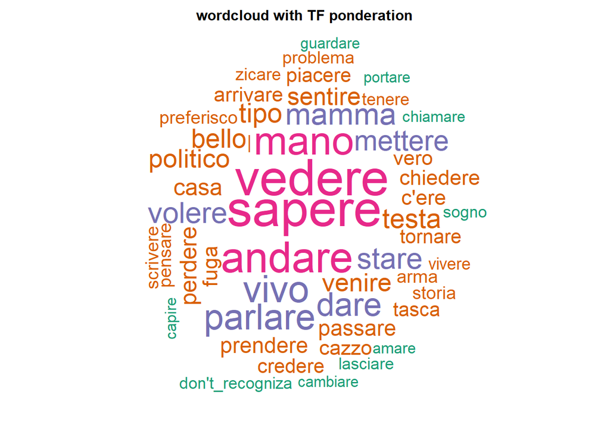

```r
par(mar=c(1,1,0.5,1))
wordcloud(words = wordlist$words, freq = wordlist$freqs, scale = c(3.5, 0.35),
          max.words = 50, random.order = F,
          colors = RColorBrewer::brewer.pal(name = "Dark2", n = 4))
text(0.5, 1, "wordcloud with TF ponderation", font = 2)
```

It could be interesting to know in which songs a given word appears, especially if it seems an odd one. We can use this function.

```r
count <- 1
for(i in songs$lyrics){
  if(grepl("mamma", i)){
    print(songs$title[[count]])
  }
  count <- count + 1
}
```

```
## [1] "Chi c*zzo me lo"
## [1] "Mammamiamamma"
## [1] "Limiti"
## [1] "Nel paese dei balordi"
## [1] "Felici ma trimoni"
## [1] "Sono troppo stitico"
## [1] "Io Diventerò Qualcuno"
## [1] "La Fine Di Gaia"
## [1] "Messa In Moto"
## [1] "Fugadà"
```

## TF-IDF ponderation

It is often necessary to weight terms in the corpus on the basis of their relative importance. For example, a term which occurs frequently in a document has a strong relevance for that document, but a term which occurs frequently in many different documents is less informative for any single document and should be treated as less relevant.

To account for this situation, we are going to use the term frequency-inverse document frequency (TF-IDF) weighting.

```r
tf_idf <- dfm_tfidf(DTM)
freqs_tf_idf <- colSums(tf_idf)
words_tf_idf <- colnames(tf_idf)
wordlist_tf_idf <- data.frame(words = words_tf_idf, freqs = freqs_tf_idf)
wordlist_tf_idf %>% arrange(-freqs) %>% head(10)
```

```
##                           words    freqs
## mamma                     mamma 86.63831
## zicare                   zicare 86.53418
## fuga                       fuga 84.94036
## politico               politico 76.63069
## van_gogh               van_gogh 71.76005
## don't_recogniza don't_recogniza 68.76327
## tasca                     tasca 67.75775
## meghino                 meghino 67.53887
## ye-ye                     ye-ye 67.53887
## vivo                       vivo 65.38749
```

These are the most common terms after the applied weighting.

Let’s have a look at the new word cloud.

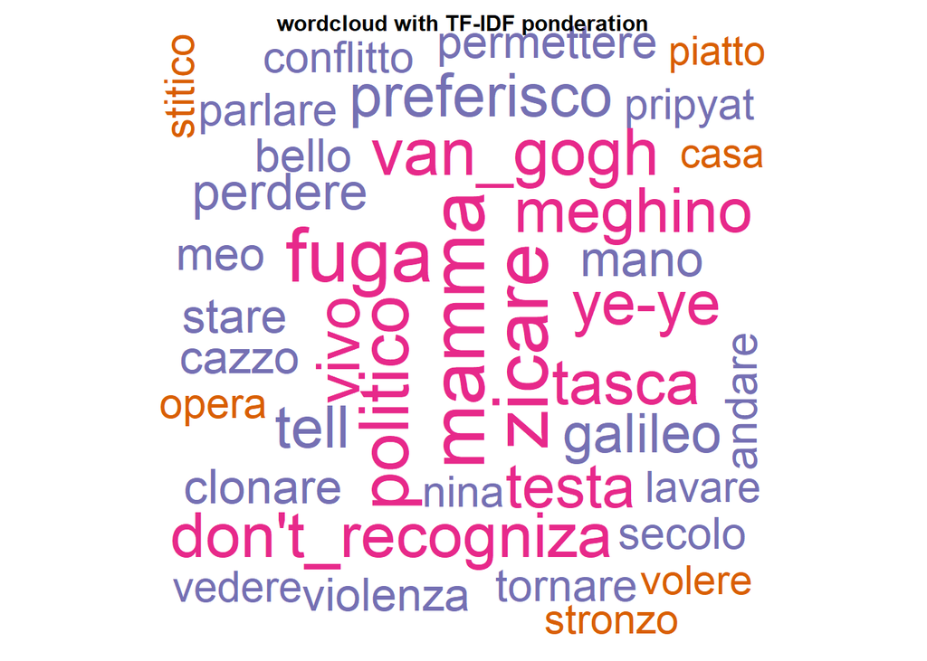

```r
par(mar=c(1,1,0.5,1))
wordcloud(words = wordlist_tf_idf$words, freq = wordlist_tf_idf$freqs,
          scale = c(3.5, 0.35), max.words = 50, random.order = F,
          colors = RColorBrewer::brewer.pal(name = "Dark2", n = 4))
text(0.5, 1, "wordcloud with TF-IDF ponderation", font = 2)
```

## Group by albums

Let’s redo some of our previous analysis, this time considering the entire albums as documents, rather than individual songs.

```r
lemmatized_lyrics_by_album <- songs %>% group_by(album) %>%
  summarise(lemmatized = paste(lemmatized, collapse = " ")) %>% arrange(match(album, albums))
corpus_album <- lemmatized_lyrics_by_album$lemmatized %>% corpus()

DTM_album <- corpus_album %>% tokens() %>% dfm()
DTM_album
```

```
## Document-feature matrix of: 8 documents, 8,677 features (80.97% sparse) and 0 docvars.
##        features
## docs    rappresentare perdere mc ripetere passo risultato sentire arrivato arma
##   text1             1       5  1        2     1         1       7        1    8
##   text2             0       2  0        0     4         0       8        0    4
##   text3             0       4  0        0     1         1      18        0    1
##   text4             0       2  0        1     3         1       6        0    3
##   text5             0      42  0        1     2         0       7        0    2
##   text6             1       1  0        1     6         0       5        0    7
##        features
## docs    |
##   text1 8
##   text2 5
##   text3 1
##   text4 2
##   text5 2
##   text6 7
## [ reached max_ndoc ... 2 more documents, reached max_nfeat ... 8,667 more features ]
```

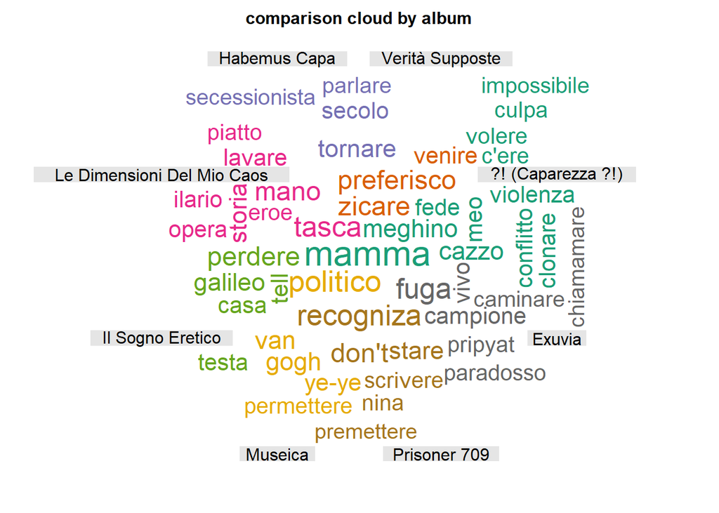

```r
docnames(DTM_album) <- lemmatized_lyrics_by_album$album
wordlist_album <- DTM_album %>% as.matrix() %>% t()
par(mar=c(0,0,0,0))
comparison.cloud(wordlist_album, scale = c(2, 1), max.words = 50, random.order = F,
                 title.size = 1, colors = RColorBrewer::brewer.pal(name = "Dark2", n = 8))
text(0.5, 1, "comparison cloud by album", font = 2)
```

We can recognize some iconic songs from each album by looking at the words: *conflitto* from *Il Conflitto* (*?!*), *secessionista* from *Inno Verdano* (*Habemus Capa*), *campione* from *Campione dei Novanta* (*Exuvia*), and more.

## Co-occurrence analysis

Next, we are going to analyze the co-occurrence of words in order to find terms which tend to appear in the same documents.

```r
binDTM <- DTM %>% dfm_trim(min_docfreq = 10) %>% dfm_weight("boolean")
coocCounts <- t(binDTM) %*% binDTM
as.matrix(coocCounts[100:102, 100:102])
```

```
##         libro resto leggere
## libro      15     2       4
## resto       2    12       1
## leggere     4     1      14
```

For example, the words *libro* and *leggere* appear together in four documents. The diagonal elements of the matrix are the total occurrencies of the word.

Let’s calculate some co-occurrence measurements for the words *lavoro* and then *leggere*: Mutual Information, Dice, and Log-Likelihood.

```r
coocTerm <- "lavoro"
k <- nrow(binDTM)
ki <- sum(binDTM[, coocTerm])
kj <- colSums(binDTM)
names(kj) <- colnames(binDTM)
kij <- coocCounts[coocTerm, ]

mutualInformationSig <- log(k * kij / (ki * kj))
mutualInformationSig <- mutualInformationSig[order(mutualInformationSig, decreasing = TRUE)]

dicesig <- 2 * kij / (ki + kj)
dicesig <- dicesig[order(dicesig, decreasing=TRUE)]

logsig <- 2 * ((k * log(k)) - (ki * log(ki)) - (kj * log(kj)) + (kij * log(kij))
               + (k - ki - kj + kij) * log(k - ki - kj + kij)
               + (ki - kij) * log(ki - kij) + (kj - kij) * log(kj - kij)
               - (k - ki) * log(k - ki) - (k - kj) * log(k - kj))
logsig <- logsig[order(logsig, decreasing=T)]

resultOverView <- data.frame(
  names(sort(kij, decreasing=T)[1:10]), sort(kij, decreasing=T)[1:10],
  names(mutualInformationSig[1:10]), mutualInformationSig[1:10],
  names(dicesig[1:10]), dicesig[1:10],
  names(logsig[1:10]), logsig[1:10],
  row.names = NULL)
colnames(resultOverView) <- c("Freq-terms", "Freq", "MI-terms", "MI", "Dice-Terms", "Dice", "LL-Terms", "LL")
print(resultOverView)
```

```
##    Freq-terms Freq MI-terms        MI Dice-Terms      Dice LL-Terms        LL
## 1      lavoro   12   lavoro 2.3749058     lavoro 1.0000000 politico 12.737294
## 2     mettere    7 politico 1.6817586   politico 0.4545455  giocare  8.124581
## 3      sapere    7  servire 1.2762935    giocare 0.3703704  servire  6.205002
## 4        mano    6  giocare 1.2762935    servire 0.3333333 arrivare  5.602518
## 5     parlare    6   facile 1.1709330    restare 0.3125000  restare  5.375092
## 6    arrivare    6  vecchio 1.0756228   scrivere 0.3125000 scrivere  5.375092
## 7     passare    6    donna 1.0531499   arrivare 0.3076923    donna  4.514591
## 8      vedere    5  restare 0.9886114      donna 0.2962963    gioco  4.063507
## 9    prendere    5    gioco 0.9886114      gioco 0.2857143    punto  4.063507
## 10     andare    5    punto 0.9886114      punto 0.2857143   facile  3.852185
```

```r
coocTerm <- "leggere"
k <- nrow(binDTM)
ki <- sum(binDTM[, coocTerm])
kj <- colSums(binDTM)
names(kj) <- colnames(binDTM)
kij <- coocCounts[coocTerm, ]

mutualInformationSig <- log(k * kij / (ki * kj))
mutualInformationSig <- mutualInformationSig[order(mutualInformationSig, decreasing = TRUE)]

dicesig <- 2 * kij / (ki + kj)
dicesig <- dicesig[order(dicesig, decreasing=TRUE)]

logsig <- 2 * ((k * log(k)) - (ki * log(ki)) - (kj * log(kj)) + (kij * log(kij))
               + (k - ki - kj + kij) * log(k - ki - kj + kij)
               + (ki - kij) * log(ki - kij) + (kj - kij) * log(kj - kij)
               - (k - ki) * log(k - ki) - (k - kj) * log(k - kj))
logsig <- logsig[order(logsig, decreasing=T)]

resultOverView <- data.frame(
  names(sort(kij, decreasing=T)[1:10]), sort(kij, decreasing=T)[1:10],
  names(mutualInformationSig[1:10]), mutualInformationSig[1:10],
  names(dicesig[1:10]), dicesig[1:10],
  names(logsig[1:10]), logsig[1:10],
  row.names = NULL)
colnames(resultOverView) <- c("Freq-terms", "Freq", "MI-terms", "MI", "Dice-Terms", "Dice", "LL-Terms", "LL")
print(resultOverView)
```

```
##    Freq-terms Freq    MI-terms        MI  Dice-Terms      Dice    LL-Terms
## 1     leggere   14     leggere 2.2207551     leggere 1.0000000      facile
## 2      sapere    9      facile 1.3044643      facile 0.3333333 interessare
## 3     mettere    8 interessare 1.2091542 interessare 0.3200000      bianco
## 4      vedere    8      bianco 1.0421001      bianco 0.2962963        vero
## 5      andare    7      voglia 1.0167823        vero 0.2926829       libro
## 6      volere    7      verità 1.0167823       libro 0.2758621      voglia
## 7        mano    6       libro 0.8989992      capire 0.2702703      verità
## 8     parlare    6      lavoro 0.8344607      volere 0.2592593      capire
## 9        vero    6        nero 0.7738361        nero 0.2580645        nero
## 10    sentire    5        vero 0.7166777      voglia 0.2500000    guardare
##          LL
## 1  6.477521
## 2  5.693482
## 3  4.423185
## 4  3.915501
## 5  3.437913
## 6  3.048969
## 7  3.048969
## 8  2.913518
## 9  2.655799
## 10 2.626559
```

## Co-occurrence visualization

To visualize co-occurrence for a single term, we may use a graph which displays the terms co-occurrence network (including secondary co-occurrence levels).

```r
source("resources/calculateCoocStatistics.R")
numberOfCoocs <- 10
coocTerm <- "libro"
coocs <- calculateCoocStatistics(coocTerm, binDTM, measure="LOGLIK")
print(coocs[1:numberOfCoocs])
```

```
##     vero    paura  nascere   brutto  parlare    letto    amico  leggere
## 8.906301 6.536650 5.939264 5.939264 4.471098 3.941007 3.816210 3.437913
## arrivare       re
## 3.251808 2.994014
```

```r
resultGraph <- data.frame(from = character(), to = character(), sig = numeric(0))
tmpGraph <- data.frame(from = character(), to = character(), sig = numeric(0))

# Fill the data.frame to produce the correct number of lines
tmpGraph[1:numberOfCoocs, 3] <- coocs[1:numberOfCoocs]
# Entry of the search word into the first column in all lines
tmpGraph[, 1] <- coocTerm
# Entry of the co-occurrences into the second column of the respective line
tmpGraph[, 2] <- names(coocs)[1:numberOfCoocs]
# Set the significances
tmpGraph[, 3] <- coocs[1:numberOfCoocs]

# Attach the triples to resultGraph
resultGraph <- rbind(resultGraph, tmpGraph)

# Iteration over the most significant numberOfCoocs co-occurrences of the search term
for (i in 1:numberOfCoocs){

  # Calling up the co-occurrence calculation for term i from the search words co-occurrences
  newCoocTerm <- names(coocs)[i]
  coocs2 <- calculateCoocStatistics(newCoocTerm, binDTM, measure="LOGLIK")

  #print the co-occurrences
  coocs2[1:10]

  # Structure of the temporary graph object
  tmpGraph <- data.frame(from = character(), to = character(), sig = numeric(0))
  tmpGraph[1:numberOfCoocs, 3] <- coocs2[1:numberOfCoocs]
  tmpGraph[, 1] <- newCoocTerm
  tmpGraph[, 2] <- names(coocs2)[1:numberOfCoocs]
  tmpGraph[, 3] <- coocs2[1:numberOfCoocs]

  #Append the result to the result graph
  resultGraph <- rbind(resultGraph, tmpGraph[2:length(tmpGraph[, 1]), ])
}

# Sample of some examples from resultGraph
resultGraph[sample(nrow(resultGraph), 6), ]
```

```
##        from      to      sig
## 98  leggere    nero 2.655799
## 1     libro    vero 8.906301
## 78  leggere  verità 3.048969
## 22    paura parlare 6.624673
## 39 arrivare    vivo 6.471441
## 86    letto  venere 3.426855
```

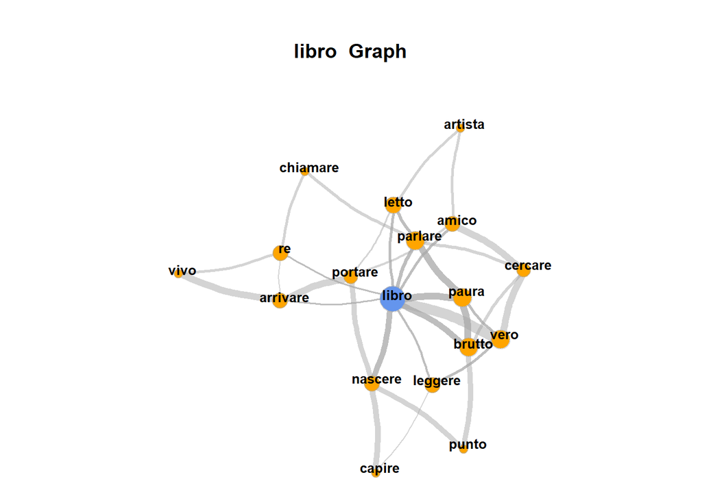

```r
# set seed for graph plot
set.seed(1)

# Create the graph object as undirected graph
graphNetwork <- graph.data.frame(resultGraph, directed = F)

# Identification of all nodes with less than 2 edges
verticesToRemove <- V(graphNetwork)[degree(graphNetwork) < 2]
# These edges are removed from the graph
graphNetwork <- delete.vertices(graphNetwork, verticesToRemove)

# Assign colors to nodes (search term blue, others orange)
V(graphNetwork)$color <- ifelse(V(graphNetwork)$name == coocTerm, 'cornflowerblue', 'orange')

# Set edge colors
E(graphNetwork)$color <- adjustcolor("DarkGray", alpha.f = .5)
# scale significance between 1 and 10 for edge width
E(graphNetwork)$width <- scales::rescale(E(graphNetwork)$sig, to = c(1, 10))

# Set edges with radius
E(graphNetwork)$curved <- 0.15
# Size the nodes by their degree of networking (scaled between 5 and 15)
V(graphNetwork)$size <- scales::rescale(log(degree(graphNetwork)), to = c(5, 15))

# Define the frame and spacing for the plot
par(mai=c(0,0,1,0))

# Final Plot
plot(
  graphNetwork,
  layout = layout.fruchterman.reingold, # Force Directed Layout
  main = paste(coocTerm, ' Graph'),
  vertex.label.family = "sans",
  vertex.label.cex = 0.8,
  vertex.shape = "circle",
  vertex.label.dist = 0.5,          # Labels of the nodes moved slightly
  vertex.frame.color = adjustcolor("darkgray", alpha.f = .5),
  vertex.label.color = 'black',     # Color of node names
  vertex.label.font = 2,            # Font of node names
  vertex.label = V(graphNetwork)$name,      # node names
  vertex.label.cex = 1 # font size of node names
)
```

## Sentiment analysis

We are now going to perform a sentiment analysis on the lyrics of the songs. At [this link](https://saifmohammad.com/WebPages/NRC-Emotion-Lexicon.htm), you can download NRC emotion lexicons in different languages. It allows you to catalogue words in positive / negative classes and even emotions, as we will see later.

```r
sentiment_lexicon <- read.table("resources/Italian-NRC-EmoLex.txt",
                                header = TRUE, sep = "\t")
sentiment_lexicon_corpus <- sentiment_lexicon %>% filter(Italian.Word %in% colnames(DTM))
positive_terms <- sentiment_lexicon_corpus %>% filter(positive == 1) %>%
  select(Italian.Word) %>% pull()
negative_terms <- sentiment_lexicon_corpus %>% filter(positive == 0) %>%
  select(Italian.Word) %>% pull()
counts_positive <- rowSums(DTM[, positive_terms])
counts_negative <- rowSums(DTM[, negative_terms])
counts_all_terms <- rowSums(DTM)
relative_sentiment_frequencies <- data.frame(
  positive = counts_positive / counts_all_terms,
  negative = counts_negative / counts_all_terms
)
sentiments_by_album <- aggregate(relative_sentiment_frequencies,
                                 by = list(album = songs$album), mean)

head(sentiments_by_album)
```

```
##                        album   positive  negative
## 1          ?! (Caparezza ?!) 0.07331877 0.2368422
## 2                     Exuvia 0.08534713 0.2859161
## 3               Habemus Capa 0.05526262 0.2870167
## 4           Il Sogno Eretico 0.06532196 0.2448593
## 5 Le Dimensioni Del Mio Caos 0.07163986 0.2457957
## 6                    Museica 0.05849356 0.2971109
```

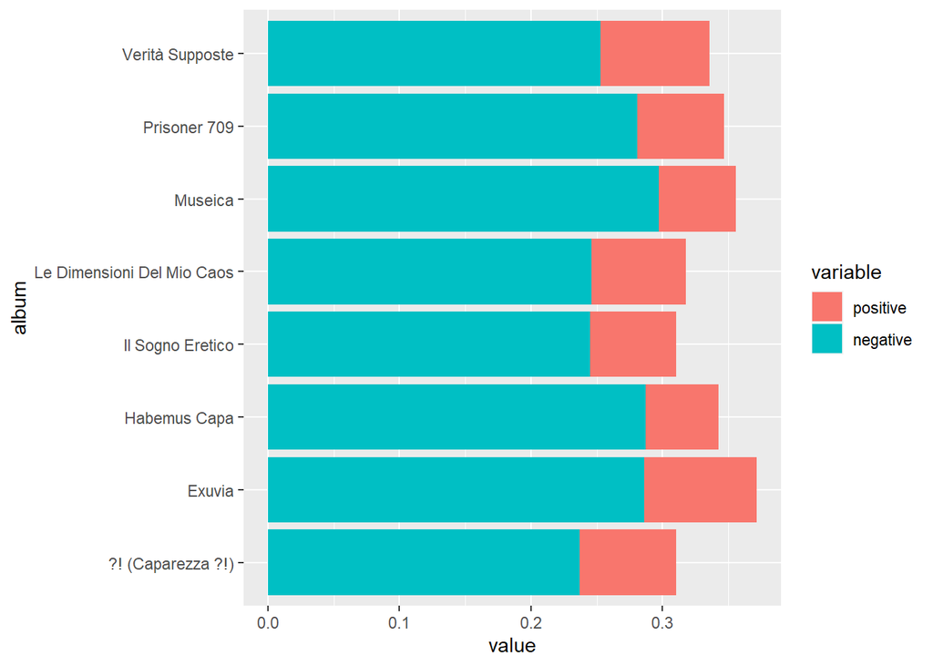

```r
df_sentiment <- melt(sentiments_by_album, id.vars = "album")
ggplot(data = df_sentiment, aes(x = album, y = value, fill = variable)) +
  geom_bar(stat="identity", position="stack") + coord_flip()
```

Here we have catalogued every single word, then grouped words by albums and visualized the sentiment distribution for each album. We see that the sentiment is mostly negative for every single one. It has probably to do with the topics that appear in Caparezza’s songs, who is notoriously a socially engaged singer and therefore often criticizes the hypocrisy of society.

It would be interesting to know if there is at least one song with more positive words than negative ones. Let’s find out.

```r
positive_songs <- aggregate(
  relative_sentiment_frequencies, by = list(album = songs$title),
  mean) %>% filter(positive > negative)
positive_songs
```

```
##                          album  positive  negative
## 1 Chi Se Ne Frega Della Musica 0.2097561 0.2000000
## 2                       Fugadà 0.2131783 0.1627907
## 3         Uomini di molta fede 0.1634615 0.1250000
```

Here they are. *Chi se ne frega della musica*, *Fugadà* and *Uomini di molta fede* have been classified as mostly positive songs.

## Emotion analysis

For the last part of our analysis, we are going to look at the emotions, specifically anger, fear, joy and sadness, using the same NCR lexicon as before.

```r
anger_terms <- sentiment_lexicon_corpus %>% filter(anger == 1) %>%
  select(Italian.Word) %>% pull()
fear_terms <- sentiment_lexicon_corpus %>% filter(fear == 1) %>%
  select(Italian.Word) %>% pull()
joy_terms <- sentiment_lexicon_corpus %>% filter(joy == 1) %>%
  select(Italian.Word) %>% pull()
sadness_terms <- sentiment_lexicon_corpus %>% filter(sadness == 1) %>%
  select(Italian.Word) %>% pull()

counts_anger <- rowSums(DTM[, anger_terms])
counts_fear <- rowSums(DTM[, fear_terms])
counts_joy <- rowSums(DTM[, joy_terms])
counts_sadness <- rowSums(DTM[, sadness_terms])

relative_emotion_frequencies <- data.frame(
  anger = counts_anger / counts_all_terms,
  fear = counts_fear / counts_all_terms,
  joy = counts_joy / counts_all_terms,
  sadness = counts_sadness / counts_all_terms
)

emotions_by_album <- aggregate(relative_emotion_frequencies,
                                 by = list(album = songs$album), mean)

head(emotions_by_album)
```

```
##                        album      anger       fear        joy    sadness
## 1          ?! (Caparezza ?!) 0.03095043 0.04822721 0.03773830 0.03649381
## 2                     Exuvia 0.02946261 0.04224000 0.04497954 0.02364693
## 3               Habemus Capa 0.03003343 0.04499670 0.02233911 0.02429495
## 4           Il Sogno Eretico 0.02612953 0.02751830 0.02772947 0.03357154
## 5 Le Dimensioni Del Mio Caos 0.02456764 0.03229070 0.02613714 0.01702260
## 6                    Museica 0.06870738 0.07543487 0.02139712 0.04249225
```

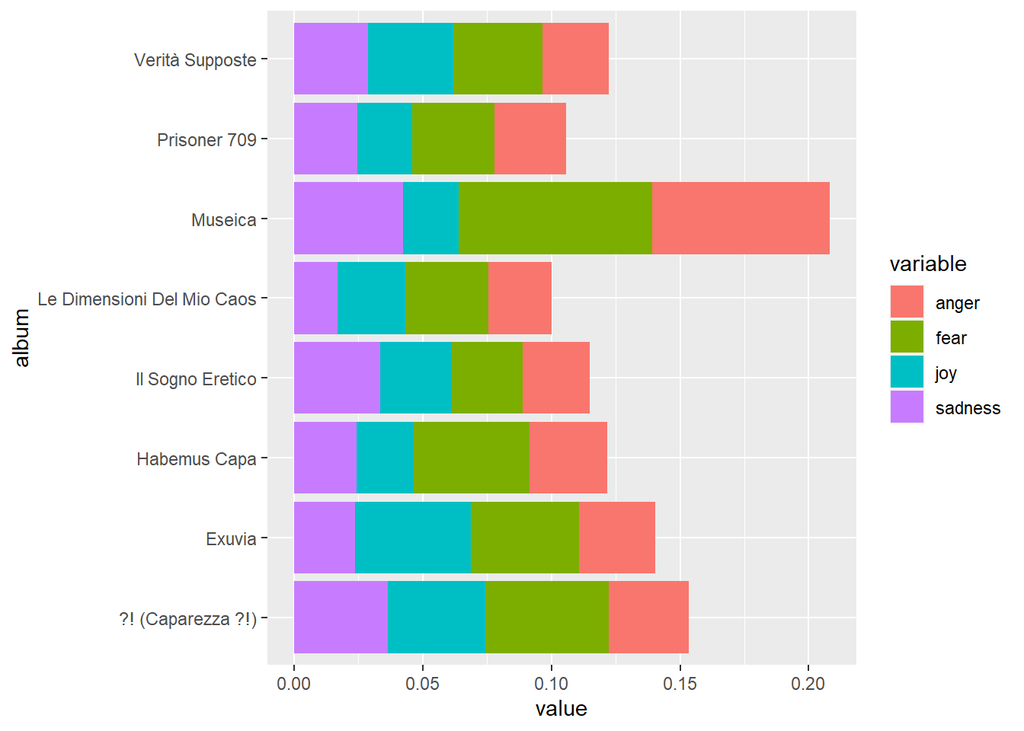

```r
df_emotions <- melt(emotions_by_album, id.vars = "album")
ggplot(data = df_emotions, aes(x = album, y = value, fill = variable)) +
  geom_bar(stat="identity", position="stack") + coord_flip()
```

Anger and fear are the prevailing emotions and they are mostly noticeable in the *Museica* album. The album where joy shares a larger percentage is *Exuvia*.